# ————————————————————————-

####1a: Uploading all the sheets

```r
library(readxl)
library(dplyr)
library(magrittr)
library(knitr)
file_path <- '/Users/laurynpisciotto/Desktop/Respo data/T0_MCAP_run_7_light_7_6_2023.xlsx'
T0_list <- list()
sheet_names <- c('SABD0000000003, Ch 2', 'SABD0000000003, Ch 3', 'SABD0000000003, Ch 4',
                 'SABD0000000003, Ch 5', 'SABD0000000003, Ch 6', 'SABD0000000003, Ch 7',
                 'SABD0000000003, Ch 8', 'SABD0000000003, Ch 9', 'SABD0000000003, Ch 10')

for (sheet_name in sheet_names) {
  df <- read_excel(file_path, sheet = sheet_name)
  T0_list[[sheet_name]] <- df
}
for (i in 1:length(sheet_names)) {
  assign(paste0("ch", i + 1), T0_list[[sheet_names[i]]], envir = .GlobalEnv)
}
```

# ————————————————————————-

####2a: Renaming the third column

```r
T0_list <- list(ch2, ch3, ch4, ch5, ch6, ch7, ch8, ch9, ch10)
for (i in 1:length(T0_list)) {
  names(T0_list[[i]])[3] <- "Delta_Time"
}
T0_list
```

```
## [[1]]
## # A tibble: 1,205 × 23
##        Id Date                Delta_Time Sensor Calibration         User  Oxygen
##     <dbl> <dttm>                   <dbl> <chr>  <dttm>              <chr>  <dbl>
##  1 227446 2023-07-06 12:24:54     0      chann… 2023-06-27 13:36:20 defa…   217.
##  2 227455 2023-07-06 12:24:57     0.0517 chann… 2023-06-27 13:36:20 defa…   216.
##  3 227464 2023-07-06 12:25:00     0.102  chann… 2023-06-27 13:36:20 defa…   216.
##  4 227473 2023-07-06 12:25:03     0.152  chann… 2023-06-27 13:36:20 defa…   216.
##  5 227482 2023-07-06 12:25:06     0.202  chann… 2023-06-27 13:36:20 defa…   215.
##  6 227491 2023-07-06 12:25:09     0.253  chann… 2023-06-27 13:36:20 defa…   215.
##  7 227500 2023-07-06 12:25:12     0.302  chann… 2023-06-27 13:36:20 defa…   215.
##  8 227509 2023-07-06 12:25:15     0.352  chann… 2023-06-27 13:36:20 defa…   214.
##  9 227518 2023-07-06 12:25:18     0.402  chann… 2023-06-27 13:36:20 defa…   214.
## 10 227527 2023-07-06 12:25:21     0.452  chann… 2023-06-27 13:36:20 defa…   214.
## # ℹ 1,195 more rows
## # ℹ 16 more variables: `Oxygen Unit` <chr>, Temperature <dbl>,
## #   `Temperature Unit` <chr>, Pressure <dbl>, `Pressure Unit` <chr>,
## #   Mode <chr>, `Salinity [pmil]` <dbl>, `User Signal Intensity` <dbl>,
## #   Error <lgl>, `Error Code` <dbl>, `Phase [°]` <dbl>, `Amplitude [µV]` <dbl>,
## #   `Reference Amplitude [µV]` <dbl>, `Signal LED Current` <dbl>,
## #   `Reference LED Current` <dbl>, `Battery [V]` <lgl>
##
## [[2]]
## # A tibble: 1,205 × 23
##        Id Date                Delta_Time Sensor Calibration         User  Oxygen
##     <dbl> <dttm>                   <dbl> <chr>  <dttm>              <chr>  <dbl>
##  1 227451 2023-07-06 12:24:54     0      chann… 2023-06-27 13:41:16 defa…   210.
##  2 227457 2023-07-06 12:24:57     0.0517 chann… 2023-06-27 13:41:16 defa…   210.
##  3 227469 2023-07-06 12:25:00     0.102  chann… 2023-06-27 13:41:16 defa…   210.
##  4 227475 2023-07-06 12:25:03     0.151  chann… 2023-06-27 13:41:16 defa…   210.
##  5 227487 2023-07-06 12:25:06     0.202  chann… 2023-06-27 13:41:16 defa…   209.
##  6 227496 2023-07-06 12:25:09     0.252  chann… 2023-06-27 13:41:16 defa…   209.
##  7 227505 2023-07-06 12:25:12     0.302  chann… 2023-06-27 13:41:16 defa…   209.
##  8 227511 2023-07-06 12:25:15     0.352  chann… 2023-06-27 13:41:16 defa…   209.
##  9 227523 2023-07-06 12:25:18     0.402  chann… 2023-06-27 13:41:16 defa…   208.
## 10 227532 2023-07-06 12:25:21     0.452  chann… 2023-06-27 13:41:16 defa…   208.
## # ℹ 1,195 more rows
## # ℹ 16 more variables: `Oxygen Unit` <chr>, Temperature <dbl>,
## #   `Temperature Unit` <chr>, Pressure <dbl>, `Pressure Unit` <chr>,
## #   Mode <chr>, `Salinity [pmil]` <dbl>, `User Signal Intensity` <dbl>,
```

[output cut: 142 more lines]

```
##  3 227465 2023-07-06 12:25:00     0.102  chann… 2023-06-27 13:53:59 defa…   182.
##  4 227480 2023-07-06 12:25:03     0.152  chann… 2023-06-27 13:53:59 defa…   182.
##  5 227483 2023-07-06 12:25:06     0.202  chann… 2023-06-27 13:53:59 defa…   182.
##  6 227492 2023-07-06 12:25:09     0.252  chann… 2023-06-27 13:53:59 defa…   182.
##  7 227502 2023-07-06 12:25:12     0.302  chann… 2023-06-27 13:53:59 defa…   182.
##  8 227516 2023-07-06 12:25:15     0.352  chann… 2023-06-27 13:53:59 defa…   182.
##  9 227519 2023-07-06 12:25:18     0.402  chann… 2023-06-27 13:53:59 defa…   182.
## 10 227528 2023-07-06 12:25:21     0.452  chann… 2023-06-27 13:53:59 defa…   182.
## # ℹ 1,195 more rows
## # ℹ 16 more variables: `Oxygen Unit` <chr>, Temperature <dbl>,
## #   `Temperature Unit` <chr>, Pressure <dbl>, `Pressure Unit` <chr>,
## #   Mode <chr>, `Salinity [pmil]` <dbl>, `User Signal Intensity` <dbl>,
## #   Error <lgl>, `Error Code` <dbl>, `Phase [°]` <dbl>, `Amplitude [µV]` <dbl>,
## #   `Reference Amplitude [µV]` <dbl>, `Signal LED Current` <dbl>,
## #   `Reference LED Current` <dbl>, `Battery [V]` <lgl>
```

# ————————————————————————-

####3a: Adding in another column for the different channels

```r
for (i in 1:length(T0_list)) {
  channel_name <- paste0("channel_", i + 1)
  T0_list[[i]]$Channel <- as.factor(channel_name)
}
```

# ————————————————————————-

####4a: Merging all the data sheets together into one dataframe

```r
combined_df <- T0_list[[1]]
for (i in 2:length(T0_list)) {
  combined_df <- merge(combined_df, T0_list[[i]], all = TRUE)
}
```

# ————————————————————————-

####5a: Showing only selected columns of data

```r
selected_columns <- combined_df %>%
  select(Delta_Time, Oxygen, Temperature, Channel)
```

# ————————————————————————-

####6a: Plotting at entire time interval (0-61 Minutes)

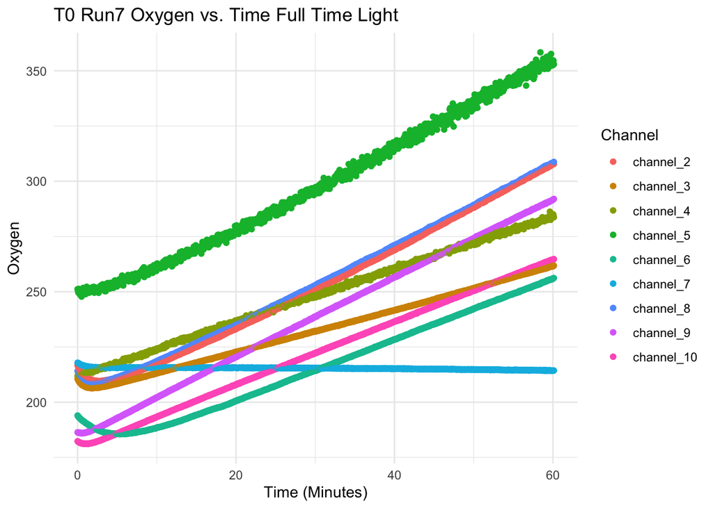

```r
library(dplyr)
start_time <- 0.0
end_time <- 61
selected_data <- selected_columns[selected_columns$Delta_Time >= start_time & selected_columns$Delta_Time <= end_time, ]
selected_data <- na.omit(selected_data)

library(ggplot2)
ggplot(selected_data, aes(x = Delta_Time, y = Oxygen, color = Channel)) +
  geom_point() +
  labs(title = "T0 Run7 Oxygen vs. Time Full Time Light",
       x = "Time (Minutes)",
       y = "Oxygen") +
  theme_minimal()
```

# ————————————————————————-

####7a: Choosing data based on specific time range (5-15 Minutes) ##Double check with graph of full run time to see if we need to use 10-20

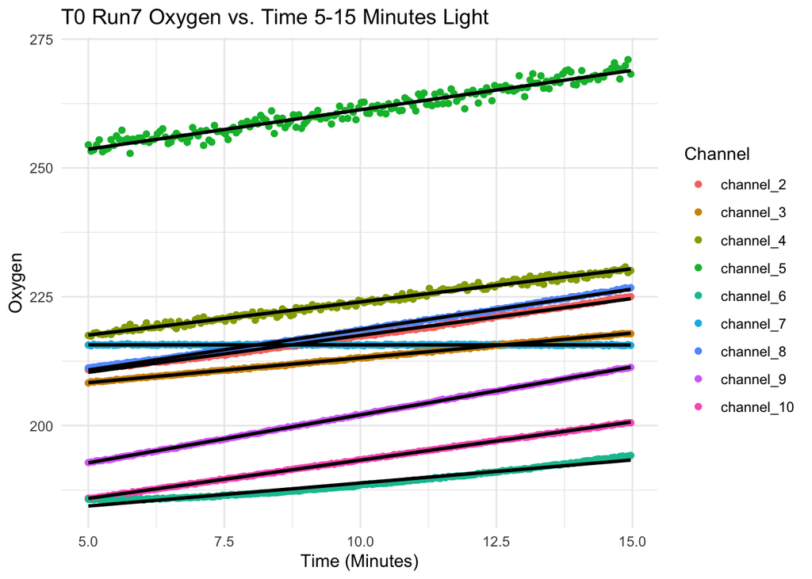

```r
library(dplyr)
start_time <- 5.0
end_time <- 15.0
selected_data <- selected_columns[selected_columns$Delta_Time >= start_time & selected_columns$Delta_Time <= end_time, ]
selected_data <- na.omit(selected_data)

library(ggplot2)
ggplot(selected_data, aes(x = Delta_Time, y = Oxygen, color = Channel, group = Channel)) +
  geom_point() +
  geom_smooth(method = "lm", se = FALSE, color = "black") +
  labs(title = "T0 Run7 Oxygen vs. Time 5-15 Minutes Light",
       x = "Time (Minutes)",
       y = "Oxygen") +
  theme_minimal()
```

# ————————————————————————-

####8a: Making a table for the slopes and finding the slope difference ####Also adding in the intercept

```r
lm_models <- lapply(split(selected_data, selected_data$Channel), function(sub_data) {
  model <- lm(Oxygen ~ Delta_Time, data = sub_data)
  coefficients <- coef(model)
  data.frame(
    Channel = unique(sub_data$Channel),
    Slope = coefficients[2],
    Intercept = coefficients[1]
  )
})

slope_table_light <- do.call(rbind, lm_models)

# Calculate the slope and intercept differences
slope_channel_7 <- slope_table_light$Slope[slope_table_light$Channel == "channel_7"]
intercept_channel_7 <- slope_table_light$Intercept[slope_table_light$Channel == "channel_7"]

slope_table_light$Light_Slope_Difference <- slope_table_light$Slope - slope_channel_7

#Adding in the avg temps
Light_average_temp <- selected_data %>%
  group_by(Channel) %>%
  summarize(Light_Avg_Temperature = mean(Temperature, na.rm = TRUE))

Light_average_temp
```

```
## # A tibble: 9 × 2
##   Channel    Light_Avg_Temperature
##   <fct>                      <dbl>
## 1 channel_2                   25.9
## 2 channel_3                   25.8
## 3 channel_4                   26.0
## 4 channel_5                   26.0
## 5 channel_6                   25.9
## 6 channel_7                   26.0
## 7 channel_8                   26.1
## 8 channel_9                   25.9
## 9 channel_10                  26.0
```

```r
slope_table_light <- merge(slope_table_light, Light_average_temp, by = "Channel", all.x = TRUE)

print(slope_table_light)
```

```
##      Channel        Slope Intercept Light_Slope_Difference
## 1 channel_10  1.487076646  178.4354              1.4890189
## 2  channel_2  1.433944193  203.1629              1.4358865
## 3  channel_3  0.960984759  203.5356              0.9629270
## 4  channel_4  1.287212296  211.1345              1.2891546
## 5  channel_5  1.530668455  245.9803              1.5326107
## 6  channel_6  0.894321220  179.9265              0.8962635
## 7  channel_7 -0.001942286  215.6886              0.0000000
## 8  channel_8  1.570310743  202.9529              1.5722530
## 9  channel_9  1.862443630  183.4700              1.8643859
##   Light_Avg_Temperature
## 1              26.01064
## 2              25.86058
## 3              25.79893
## 4              26.00416
## 5              25.95137
## 6              25.92245
## 7              26.01099
## 8              26.07364
## 9              25.93177
```

# —————————————————————————————————————————-

####1b: Repeat for dark runs

```r
library(readxl)
file_path <- '/Users/laurynpisciotto/Desktop/Respo data/T0_MCAP_run_7_dark_7_6_2023.xlsx'
T0_list <- list()
sheet_names <- c('SABD0000000003, Ch 2', 'SABD0000000003, Ch 3', 'SABD0000000003, Ch 4',
                 'SABD0000000003, Ch 5', 'SABD0000000003, Ch 6', 'SABD0000000003, Ch 7',
                 'SABD0000000003, Ch 8', 'SABD0000000003, Ch 9', 'SABD0000000003, Ch 10')

for (sheet_name in sheet_names) {
  df <- read_excel(file_path, sheet = sheet_name)
  T0_list[[sheet_name]] <- df
}
for (i in 1:length(sheet_names)) {
  assign(paste0("ch", i + 1), T0_list[[sheet_names[i]]], envir = .GlobalEnv)
}
```

# ————————————————————————-

####2b: Renaming the third column

```r
T0_list <- list(ch2, ch3, ch4, ch5, ch6, ch7, ch8, ch9, ch10)
for (i in 1:length(T0_list)) {
  names(T0_list[[i]])[3] <- "Delta_Time"
}
T0_list
```

```
## [[1]]
## # A tibble: 405 × 23
##        Id Date                Delta_Time Sensor Calibration         User  Oxygen
##     <dbl> <dttm>                   <dbl> <chr>  <dttm>              <chr>  <dbl>
##  1 238273 2023-07-06 13:48:02     0      chann… 2023-06-27 13:36:20 defa…   228.
##  2 238282 2023-07-06 13:48:05     0.0445 chann… 2023-06-27 13:36:20 defa…   228.
##  3 238291 2023-07-06 13:48:08     0.0946 chann… 2023-06-27 13:36:20 defa…   228.
##  4 238300 2023-07-06 13:48:11     0.145  chann… 2023-06-27 13:36:20 defa…   228.
##  5 238309 2023-07-06 13:48:14     0.195  chann… 2023-06-27 13:36:20 defa…   228.
##  6 238318 2023-07-06 13:48:17     0.245  chann… 2023-06-27 13:36:20 defa…   228.
##  7 238327 2023-07-06 13:48:20     0.294  chann… 2023-06-27 13:36:20 defa…   228.
##  8 238336 2023-07-06 13:48:23     0.344  chann… 2023-06-27 13:36:20 defa…   228.
##  9 238345 2023-07-06 13:48:26     0.395  chann… 2023-06-27 13:36:20 defa…   228.
## 10 238354 2023-07-06 13:48:29     0.445  chann… 2023-06-27 13:36:20 defa…   228.
## # ℹ 395 more rows
## # ℹ 16 more variables: `Oxygen Unit` <chr>, Temperature <dbl>,
## #   `Temperature Unit` <chr>, Pressure <dbl>, `Pressure Unit` <chr>,
## #   Mode <chr>, `Salinity [pmil]` <dbl>, `User Signal Intensity` <dbl>,
## #   Error <lgl>, `Error Code` <dbl>, `Phase [°]` <dbl>, `Amplitude [µV]` <dbl>,
## #   `Reference Amplitude [µV]` <dbl>, `Signal LED Current` <dbl>,
## #   `Reference LED Current` <dbl>, `Battery [V]` <lgl>
##
## [[2]]
## # A tibble: 405 × 23
##        Id Date                Delta_Time Sensor Calibration         User  Oxygen
##     <dbl> <dttm>                   <dbl> <chr>  <dttm>              <chr>  <dbl>
##  1 238278 2023-07-06 13:48:02     0      chann… 2023-06-27 13:41:16 defa…   221.
##  2 238287 2023-07-06 13:48:05     0.0445 chann… 2023-06-27 13:41:16 defa…   221.
##  3 238296 2023-07-06 13:48:08     0.0946 chann… 2023-06-27 13:41:16 defa…   221.
##  4 238305 2023-07-06 13:48:11     0.145  chann… 2023-06-27 13:41:16 defa…   221.
##  5 238314 2023-07-06 13:48:14     0.195  chann… 2023-06-27 13:41:16 defa…   221.
##  6 238323 2023-07-06 13:48:17     0.245  chann… 2023-06-27 13:41:16 defa…   220.
##  7 238332 2023-07-06 13:48:20     0.294  chann… 2023-06-27 13:41:16 defa…   220.
##  8 238338 2023-07-06 13:48:23     0.344  chann… 2023-06-27 13:41:16 defa…   220.
##  9 238347 2023-07-06 13:48:26     0.395  chann… 2023-06-27 13:41:16 defa…   220.
## 10 238359 2023-07-06 13:48:29     0.445  chann… 2023-06-27 13:41:16 defa…   220.
## # ℹ 395 more rows
## # ℹ 16 more variables: `Oxygen Unit` <chr>, Temperature <dbl>,
## #   `Temperature Unit` <chr>, Pressure <dbl>, `Pressure Unit` <chr>,
## #   Mode <chr>, `Salinity [pmil]` <dbl>, `User Signal Intensity` <dbl>,
```

[output cut: 142 more lines]

```
##  3 238292 2023-07-06 13:48:08     0.0946 chann… 2023-06-27 13:53:59 defa…   200.
##  4 238301 2023-07-06 13:48:11     0.145  chann… 2023-06-27 13:53:59 defa…   200.
##  5 238310 2023-07-06 13:48:14     0.195  chann… 2023-06-27 13:53:59 defa…   200.
##  6 238319 2023-07-06 13:48:17     0.245  chann… 2023-06-27 13:53:59 defa…   200.
##  7 238328 2023-07-06 13:48:20     0.294  chann… 2023-06-27 13:53:59 defa…   200.
##  8 238343 2023-07-06 13:48:23     0.345  chann… 2023-06-27 13:53:59 defa…   200.
##  9 238352 2023-07-06 13:48:26     0.395  chann… 2023-06-27 13:53:59 defa…   200.
## 10 238355 2023-07-06 13:48:29     0.445  chann… 2023-06-27 13:53:59 defa…   200.
## # ℹ 395 more rows
## # ℹ 16 more variables: `Oxygen Unit` <chr>, Temperature <dbl>,
## #   `Temperature Unit` <chr>, Pressure <dbl>, `Pressure Unit` <chr>,
## #   Mode <chr>, `Salinity [pmil]` <dbl>, `User Signal Intensity` <dbl>,
## #   Error <lgl>, `Error Code` <dbl>, `Phase [°]` <dbl>, `Amplitude [µV]` <dbl>,
## #   `Reference Amplitude [µV]` <dbl>, `Signal LED Current` <dbl>,
## #   `Reference LED Current` <dbl>, `Battery [V]` <lgl>
```

# ————————————————————————-

####3b: Adding in another column for the different channels

```r
for (i in 1:length(T0_list)) {
  channel_name <- paste0("channel_", i + 1)
  T0_list[[i]]$Channel <- as.factor(channel_name)
}
```

# ————————————————————————-

####4b: Merging all the data sheets together into one dataframe

```r
combined_df <- T0_list[[1]]
for (i in 2:length(T0_list)) {
  combined_df <- merge(combined_df, T0_list[[i]], all = TRUE)
}
```

# ————————————————————————-

####5b: Showing only selected columns of data

```r
selected_columns <- combined_df %>%
  select(Delta_Time, Oxygen, Temperature, Channel)
```

# ————————————————————————-

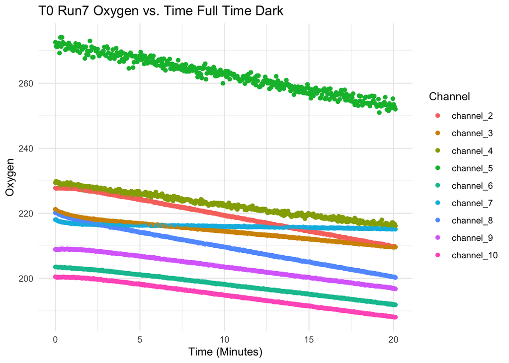

```r
library(dplyr)
start_time <- 0.0
end_time <- 61
selected_data <- selected_columns[selected_columns$Delta_Time >= start_time & selected_columns$Delta_Time <= end_time, ]
selected_data <- na.omit(selected_data)

library(ggplot2)
ggplot(selected_data, aes(x = Delta_Time, y = Oxygen, color = Channel)) +
  geom_point() +
  labs(title = "T0 Run7 Oxygen vs. Time Full Time Dark",
       x = "Time (Minutes)",
       y = "Oxygen") +
  theme_minimal()
```

# ————————————————————————-

####7b: Choosing data based on specific time range (5-15 Minutes) ##Double check with graph of full run time to see if we need to use 10-20

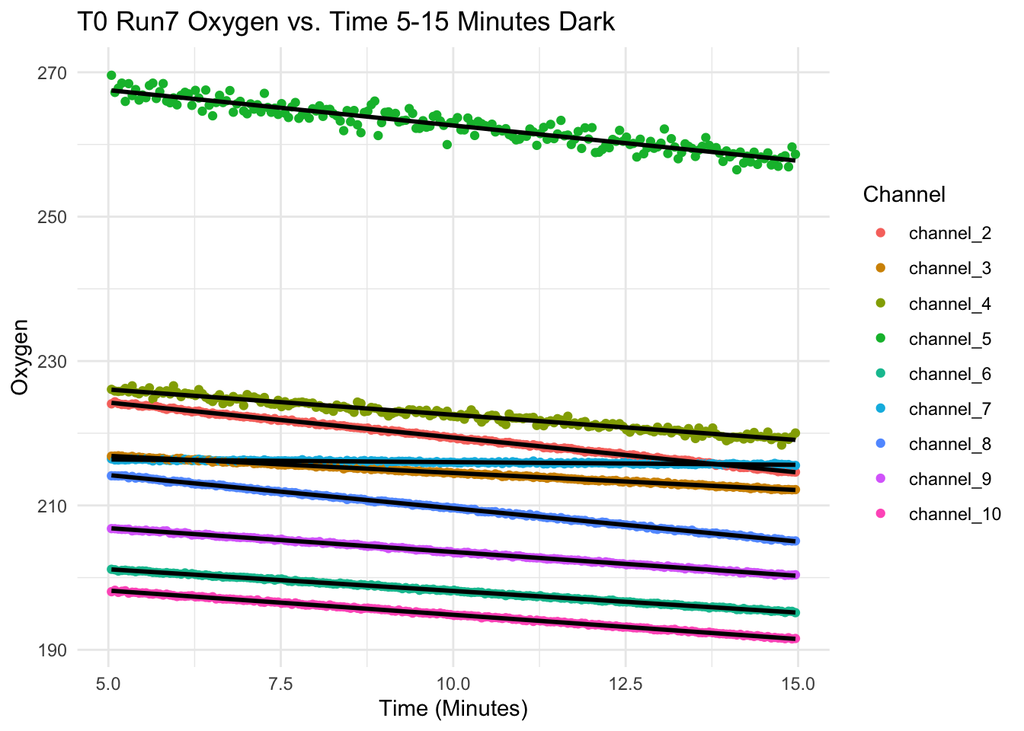

```r
library(dplyr)
start_time <- 5.0
end_time <- 15.0
selected_data <- selected_columns[selected_columns$Delta_Time >= start_time & selected_columns$Delta_Time <= end_time, ]
selected_data <- na.omit(selected_data)

library(ggplot2)
ggplot(selected_data, aes(x = Delta_Time, y = Oxygen, color = Channel, group = Channel)) +
  geom_point() +
  geom_smooth(method = "lm", se = FALSE, color = "black") +
  labs(title = "T0 Run7 Oxygen vs. Time 5-15 Minutes Dark",
       x = "Time (Minutes)",
       y = "Oxygen") +
  theme_minimal()
```

# ————————————————————————-

####8b: Making a table for the slopes and finding the slope difference ####Also adding in the intercept

```r
lm_models <- lapply(split(selected_data, selected_data$Channel), function(sub_data) {
  model <- lm(Oxygen ~ Delta_Time, data = sub_data)
  coefficients <- coef(model)
  data.frame(
    Channel = unique(sub_data$Channel),
    Slope = coefficients[2],
    Intercept = coefficients[1]
  )
})

slope_table_dark <- do.call(rbind, lm_models)

# Calculate the slope and intercept differences
slope_channel_7 <- slope_table_dark$Slope[slope_table_dark$Channel == "channel_7"]
intercept_channel_7 <- slope_table_dark$Intercept[slope_table_dark$Channel == "channel_7"]

slope_table_dark$Dark_Slope_Difference <- slope_table_dark$Slope - slope_channel_7

Dark_average_temp <- selected_data %>%
  group_by(Channel) %>%
  summarize(Dark_Avg_Temperature = mean(Temperature, na.rm = TRUE))

Dark_average_temp
```

```
## # A tibble: 9 × 2
##   Channel    Dark_Avg_Temperature
##   <fct>                     <dbl>
## 1 channel_2                  26.0
## 2 channel_3                  25.9
## 3 channel_4                  26.1
## 4 channel_5                  26.0
## 5 channel_6                  26.0
## 6 channel_7                  26.0
## 7 channel_8                  26.1
## 8 channel_9                  25.9
## 9 channel_10                 26.0
```

```r
slope_table_dark <- merge(slope_table_dark, Dark_average_temp, by = "Channel", all.x = TRUE)

print(slope_table_dark)
```

```
##      Channel       Slope Intercept Dark_Slope_Difference Dark_Avg_Temperature
## 1 channel_10 -0.67143483  201.5623            -0.5973379             26.02694
## 2  channel_2 -0.96924471  229.0996            -0.8951477             25.95227
## 3  channel_3 -0.47494725  219.2468            -0.4008503             25.94230
## 4  channel_4 -0.70086600  229.5633            -0.6267690             26.07268
## 5  channel_5 -0.97903851  272.4224            -0.9049415             25.99472
## 6  channel_6 -0.60111642  204.1631            -0.5270194             25.95319
## 7  channel_7 -0.07409697  216.7329             0.0000000             26.02210
## 8  channel_8 -0.92119292  218.8115            -0.8470959             26.12803
## 9  channel_9 -0.66099648  210.1600            -0.5868995             25.93062
```

# ——————————————————————————————————————————-

####9: Merging the two slope tables together & Light slope diff - Dark slope diff = Net Environmental Production (NEP)

```r
merged_slope_table <- merge(slope_table_light, slope_table_dark, by = "Channel", suffixes = c("_Light", "_Dark"))

merged_slope_table$NEP <- merged_slope_table$Light_Slope_Difference - merged_slope_table$Dark_Slope_Difference

merged_slope_table <- merged_slope_table %>%
  arrange(as.numeric(gsub("channel_", "", Channel)))

print(merged_slope_table)
```

```
##      Channel  Slope_Light Intercept_Light Light_Slope_Difference
## 1  channel_2  1.433944193        203.1629              1.4358865
## 2  channel_3  0.960984759        203.5356              0.9629270
## 3  channel_4  1.287212296        211.1345              1.2891546
## 4  channel_5  1.530668455        245.9803              1.5326107
## 5  channel_6  0.894321220        179.9265              0.8962635
## 6  channel_7 -0.001942286        215.6886              0.0000000
## 7  channel_8  1.570310743        202.9529              1.5722530
## 8  channel_9  1.862443630        183.4700              1.8643859
## 9 channel_10  1.487076646        178.4354              1.4890189
##   Light_Avg_Temperature  Slope_Dark Intercept_Dark Dark_Slope_Difference
## 1              25.86058 -0.96924471       229.0996            -0.8951477
## 2              25.79893 -0.47494725       219.2468            -0.4008503
## 3              26.00416 -0.70086600       229.5633            -0.6267690
## 4              25.95137 -0.97903851       272.4224            -0.9049415
## 5              25.92245 -0.60111642       204.1631            -0.5270194
## 6              26.01099 -0.07409697       216.7329             0.0000000
## 7              26.07364 -0.92119292       218.8115            -0.8470959
## 8              25.93177 -0.66099648       210.1600            -0.5868995
## 9              26.01064 -0.67143483       201.5623            -0.5973379
##   Dark_Avg_Temperature      NEP
## 1             25.95227 2.331034
## 2             25.94230 1.363777
## 3             26.07268 1.915924
## 4             25.99472 2.437552
## 5             25.95319 1.423283
## 6             26.02210 0.000000
## 7             26.12803 2.419349
## 8             25.93062 2.451285
## 9             26.02694 2.086357
```

# ————————————————————————-

####10: adding in a frag ID column to correspond with channel name ##Must change for each run—this one is M.cap for T0

```r
library(readxl)
library(dplyr)

excel_file_path <- '/Users/laurynpisciotto/Downloads/T0_MCAP_Frag_ID_List (1).xlsx'

sheet_name <- 'Run7'
frag_ids <- read_excel(excel_file_path, sheet = sheet_name)

frag_ids <- frag_ids[, c("Channel", "Frag_ID")]

merged_slope_table <- merge(merged_slope_table, frag_ids, by = "Channel", all.x = TRUE)

merged_slope_table <- merged_slope_table %>%
  arrange(as.numeric(gsub("channel_", "", Channel)))

print(merged_slope_table)
```

```
##      Channel  Slope_Light Intercept_Light Light_Slope_Difference
## 1  channel_2  1.433944193        203.1629              1.4358865
## 2  channel_3  0.960984759        203.5356              0.9629270
## 3  channel_4  1.287212296        211.1345              1.2891546
## 4  channel_5  1.530668455        245.9803              1.5326107
## 5  channel_6  0.894321220        179.9265              0.8962635
## 6  channel_7 -0.001942286        215.6886              0.0000000
## 7  channel_8  1.570310743        202.9529              1.5722530
## 8  channel_9  1.862443630        183.4700              1.8643859
## 9 channel_10  1.487076646        178.4354              1.4890189
##   Light_Avg_Temperature  Slope_Dark Intercept_Dark Dark_Slope_Difference
## 1              25.86058 -0.96924471       229.0996            -0.8951477
## 2              25.79893 -0.47494725       219.2468            -0.4008503
## 3              26.00416 -0.70086600       229.5633            -0.6267690
## 4              25.95137 -0.97903851       272.4224            -0.9049415
## 5              25.92245 -0.60111642       204.1631            -0.5270194
## 6              26.01099 -0.07409697       216.7329             0.0000000
## 7              26.07364 -0.92119292       218.8115            -0.8470959
## 8              25.93177 -0.66099648       210.1600            -0.5868995
## 9              26.01064 -0.67143483       201.5623            -0.5973379
##   Dark_Avg_Temperature      NEP Frag_ID
## 1             25.95227 2.331034  M-4-24
## 2             25.94230 1.363777  M-5-24
## 3             26.07268 1.915924  M-5-25
## 4             25.99472 2.437552  M-4-22
## 5             25.95319 1.423283  M-4-23
## 6             26.02210 0.000000   blank
## 7             26.12803 2.419349  M-4-25
## 8             25.93062 2.451285  M-5-23
## 9             26.02694 2.086357  M-5-22
```

# ————————————————————————-

####11:Exporting the final table

```r
write.csv(merged_slope_table, file = '/Users/laurynpisciotto/Desktop/682FinalProject/T0_run_7_final_analyzed.csv', row.names = FALSE)
```